# Pertemuan 2 - Regresi

Radhitya Harma

## Pemanggilan *Packages*

```r
library(dplyr)
library(TTR)
library(forecast)
library(lmtest) #digunakan untuk uji formal pendeteksian autokorelasi
```

```r
library(orcutt) #untuk membuat model regresi Cochrane-Orcutt
library(HoRM) #untuk membuat model regresi Hildreth-Lu
library(graphics)
library(TSA)
library(ggplot2)
library(corrplot)
library(RColorBrewer)
library(scales)
```

## Input Data

Data yang digunakan kali ini adalah data Fossil Fuel dengan n sebanyak 64 dengan peubah respon merupakan peubah Per Capita yakni number Per capita carbon emissions, peubah X1 yakni Gas Fuel dan peubah X2 yakni Liquid Fuel.

```r
library(rio)
datafossil <- rio::import("https://raw.githubusercontent.com/RadhityaHarma12/MPDW/main/Pertemuan%202/datafix.csv")
View(datafossil)
```

## Eksplorasi Data

Sebelum melakukan regresi, akan diperlihatkan *plot time-series* dari data fossil

```r
#Membentuk objek time series y
data.ts1<-ts(datafossil$`Per Capita`)
data.ts1
```

```
## Time Series:
## Start = 1
## End = 64
## Frequency = 1
##  [1] 1.78 1.95 2.01 1.93 2.14 2.06 2.31 2.35 2.43 2.45 2.45 2.46 2.42 2.51 2.50
## [16] 2.46 2.47 2.46 2.58 2.52 2.57 2.57 2.63 2.68 2.64 2.77 2.72 2.74 2.73 2.69
## [31] 2.55 2.63 2.65 2.71 2.80 3.11 2.92 2.92 2.89 2.92 2.99 3.20 3.15 3.22 3.19
## [46] 3.08 2.99 2.93 3.08 3.11 3.06 3.06 3.03 3.03 3.02 2.85 2.91 3.00 3.04 3.07
## [61] 2.95 2.89 2.84 2.93
```

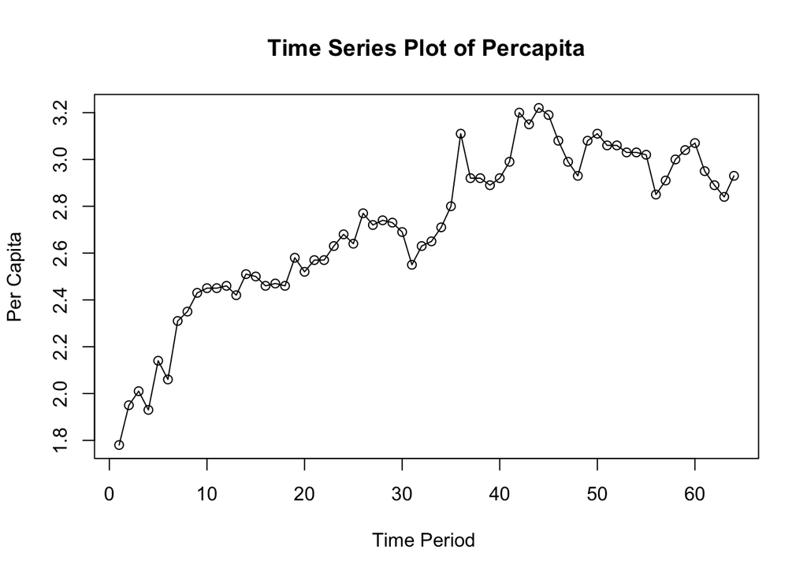

```r
#Membuat plot time series y
ts.plot(data.ts1, xlab="Time Period ", ylab="Per Capita", main= "Time Series Plot of Percapita")
points(data.ts1)
```

```r
#Membentuk objek time series x1
data.ts2<-ts(datafossil$`Gas Fuel`)
data.ts2
```

```
## Time Series:
## Start = 1
## End = 64
## Frequency = 1
##  [1] 37340 41024 41549 44043 53120 48872 52763 51193 50630 53384 54808 53640
## [13] 53623 54119 54588 52588 49578 47605 47444 40672 37611 36087 31675 31778
## [25] 29482 28578 28893 29342 29549 29460 27186 26520 25468 24456 24133 24343
## [37] 22250 21564 20207 19482 18603 15555 14372 10160  6306  3344  1710   758
## [49]   450   460   140    79    59    41    41    37    32    17    10     7
## [61]     9     6     5     4
```

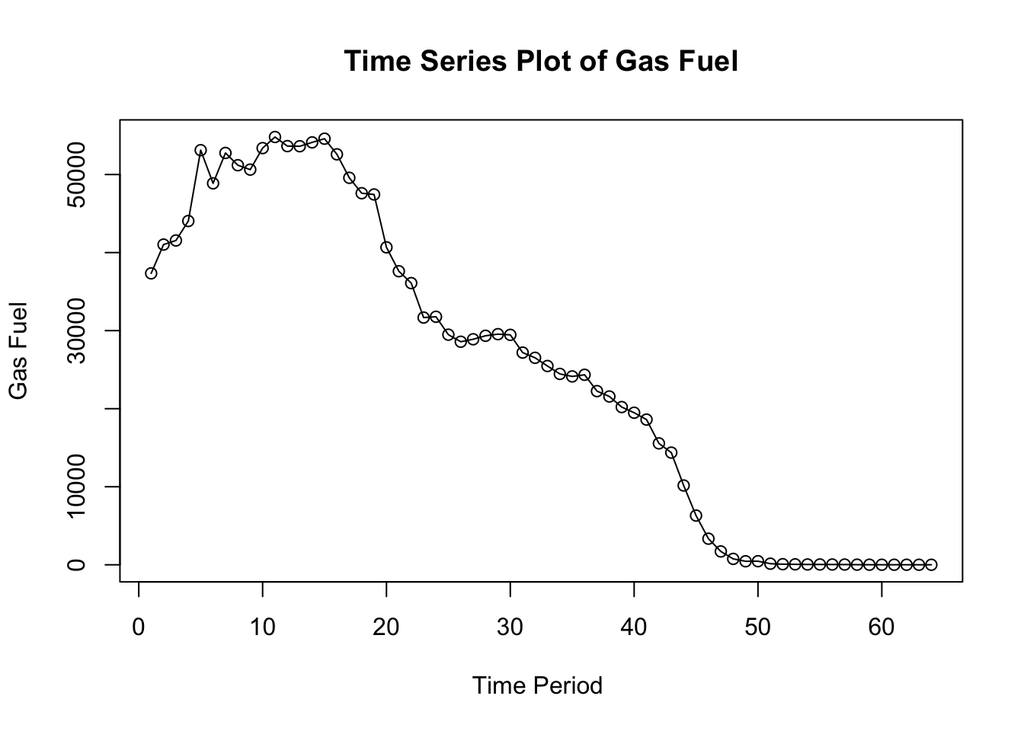

```r
#Membuat plot time series x1
ts.plot(data.ts2, xlab="Time Period ", ylab="Gas Fuel", main= "Time Series Plot of Gas Fuel")
points(data.ts2)
```

```r
#Membentuk objek time series x2
data.ts3<-ts(datafossil$`Liquid Fuel`)
data.ts3
```

```
## Time Series:
## Start = 1
## End = 64
## Frequency = 1
##  [1] 44274 43698 44872 45006 47810 47417 49926 50319 51917 52850 51185 51556
## [13] 51135 51920 52884 53631 52760 52677 54929 55268 57442 56146 57197 56582
## [25] 55729 60660 56262 52795 54873 56080 65113 51056 53507 53229 58482 69071
## [37] 67523 65527 64315 65843 74042 79630 78934 73530 72343 64953 60249 57866
## [49] 55870 51775 47120 42776 40461 37736 35178 31233 24850 22298 19822 19203
## [61] 17104 15280 14478 14633
```

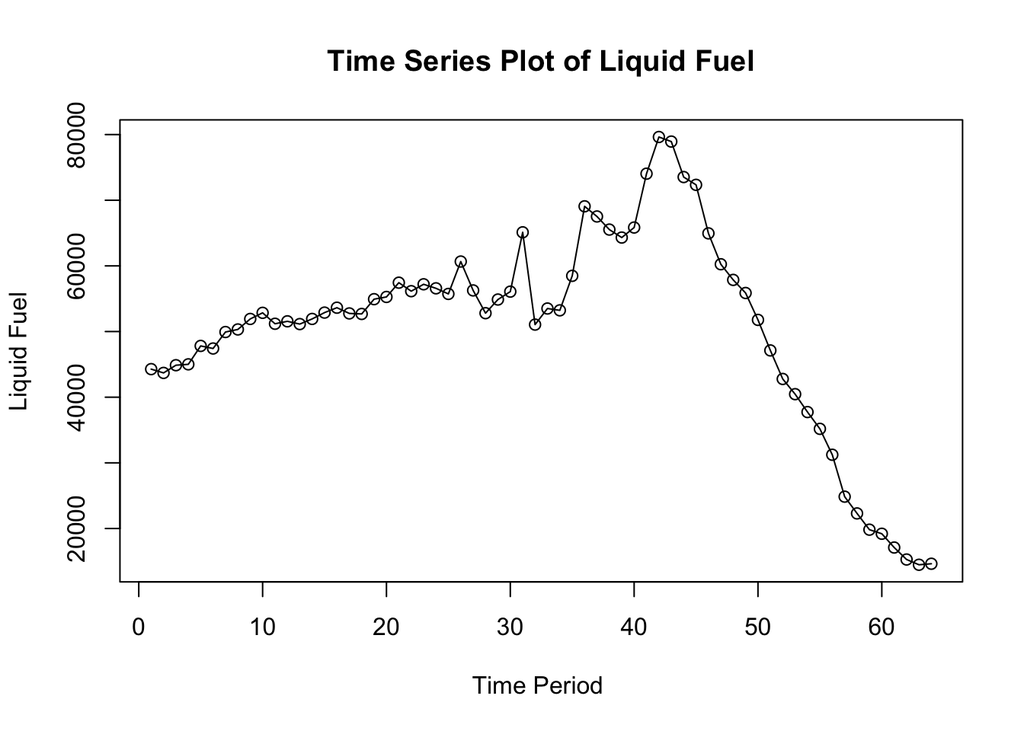

```r
#Membuat plot time series x2
ts.plot(data.ts3, xlab="Time Period ", ylab="Liquid Fuel", main= "Time Series Plot of Liquid Fuel")
points(data.ts3)
```

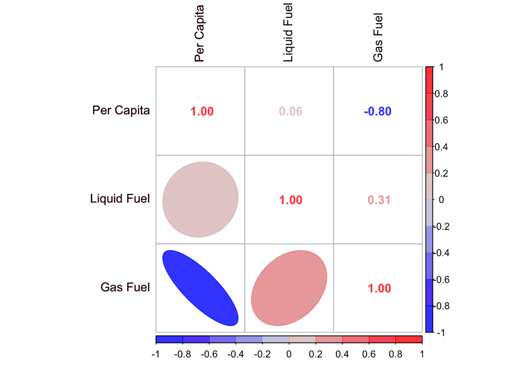

```r
# Matriks korelasi
m <- cor(datafossil)

colors <- alpha(colorRampPalette(c("blue", #Warna Bawah
                                   "#dbdbdb", #Warna Tengah
                                   "red"))(10), #Warna Atas
                                   alpha = 0.80) #Transparan

corrplot(m, method = 'ellipse', type='lower', order='original', col=colors)
corrplot(m, add=TRUE, method = 'number', type='upper', order='original',
         tl.pos = "lt",
         tl.col = "black", col=colors)
```

Setalah mengetahui adanya hubungan antar dua peubah, maka model regresi dapat ditentukan.

## Regresi

```r
#Pembuatan Model Regresi
#model regresi
model<- lm(datafossil$`Per Capita`~datafossil$`Gas Fuel`+datafossil$`Liquid Fuel`, data = datafossil)
summary(model)
```

```
##
## Call:
## lm(formula = datafossil$`Per Capita` ~ datafossil$`Gas Fuel` +
##     datafossil$`Liquid Fuel`, data = datafossil)
##
## Residuals:
##      Min       1Q   Median       3Q      Max
## -0.69615 -0.03188  0.02182  0.10021  0.24547
##
## Coefficients:
##                            Estimate Std. Error t value Pr(>|t|)
## (Intercept)               2.722e+00  7.485e-02  36.362  < 2e-16 ***
## datafossil$`Gas Fuel`    -1.551e-05  1.150e-06 -13.481  < 2e-16 ***
## datafossil$`Liquid Fuel`  7.534e-06  1.485e-06   5.074 3.92e-06 ***
## ---
## Signif. codes:  0 '***' 0.001 '**' 0.01 '*' 0.05 '.' 0.1 ' ' 1
##
## Residual standard error: 0.1734 on 61 degrees of freedom
## Multiple R-squared:  0.7497, Adjusted R-squared:  0.7415
## F-statistic: 91.33 on 2 and 61 DF,  p-value: < 2.2e-16
```

Model yang dihasilkan adalah
$$y_i=
2.722-0.00001551x_1+0.000007534x_2$$

Berdasarkan ringkasan model dapat diketahui bahwa hasil uji F memiliki *p-value* < $\alpha$ (5%). Artinya, minimal terdapat satu variabel yang berpengaruh nyata terhadap model. Hasil uji-t parsial kedua parameter regresi, yaitu intersep dan koefisien regresi juga menunjukkan hal yang sama, yaitu memiliki *p-value* < $\alpha$ (5%) sehingga nyata dalam taraf 5%. Selanjutnya dapat dilihat juga nilai $R^2=0.7497$. Artinya, sebesar 74.9% keragaman nilai peubah Per Capita dapat dijelaskan oleh peubah Gas Fuel dan Liquid Fuel. Hasil ini menunjukkan hasil yang bagus, seolah mendapatkan hasil terbaik. Namun, kita perlu melakukan uji terhadap sisaannya seperti berikut ini.

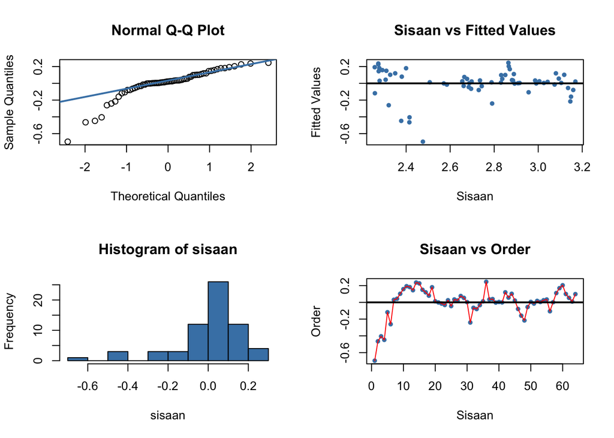

```r
#sisaan dan fitted value
sisaan<- residuals(model)
fitValue<- predict(model)

#Diagnostik dengan eksploratif
par(mfrow = c(2,2))
qqnorm(sisaan)
qqline(sisaan, col = "steelblue", lwd = 2)
plot(fitValue, sisaan, col = "steelblue", pch = 20, xlab = "Sisaan", ylab = "Fitted Values", main = "Sisaan vs Fitted Values")
abline(a = 0, b = 0, lwd = 2)
hist(sisaan, col = "steelblue")
plot(seq(1,64,1), sisaan, col = "steelblue", pch = 20, xlab = "Sisaan", ylab = "Order", main = "Sisaan vs Order")
lines(seq(1,64,1), sisaan, col = "red")
abline(a = 0, b = 0, lwd = 2)
```

```r
#Melihat Sisaan Menyebar Normal/Tidak
#H0: sisaan mengikuti sebaran normal
#H1: sisaan tidak mengikuti sebaran normal
shapiro.test(sisaan)
```

```
##
##  Shapiro-Wilk normality test
##
## data:  sisaan
## W = 0.83973, p-value = 8.114e-07
```

```r
ks.test(sisaan, "pnorm", mean=mean(sisaan), sd=sd(sisaan))
```

```
##
##  Exact one-sample Kolmogorov-Smirnov test
##
## data:  sisaan
## D = 0.19929, p-value = 0.01054
## alternative hypothesis: two-sided
```

Berdasarkan uji formal Saphiro-Wilk dan Kolmogorov-Smirnov didapatkan nilai *p-value* < $\alpha$ (5%). Artinya, belum cukup bukti untuk menyatakan sisaan berdistribusi normal.

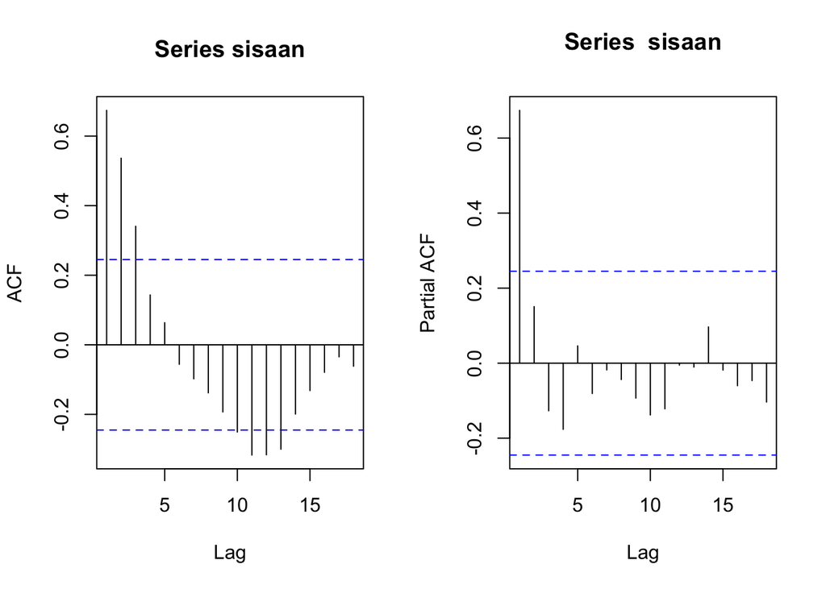

```r
#ACF dan PACF identifikasi autokorelasi
par(mfrow = c(1,2))
acf(sisaan)
pacf(sisaan)
```

Berdasarkan plot ACF dan PACF, terlihat terdapat beberapa diluar rentang batas dan ada yang signifikan. Namun, untuk lebih memastikan akan dilakukan uji formal dengan uji Durbin Watson.

```r
#Deteksi autokorelasi dengan uji-Durbin Watson
#H0: tidak ada autokorelasi
#H1: ada autokorelasi

dwtest(model)
```

```
##
##  Durbin-Watson test
##
## data:  model
## DW = 0.38291, p-value < 2.2e-16
## alternative hypothesis: true autocorrelation is greater than 0
```

Berdasarkan hasil DW Test, didapatkan nilai $DW = 0.3829$ dan *p-value* = $2.2e-16$. Berdasarkan tabel Durbin-Watson diperoleh nilai $DL = 0.6455$ dan $DU = 2.3845$. Nilai DW berada di bawah nilai DL. Artinya ,dapat dikatakan berada di daerah autokorelasi positif dan dengan nilai *p-value* < 0.05 dapat disimpulkan bahwa tolak H0, cukup bukti mengatakan adanya autokorelasi. Oleh karena itu, diperlukan penangan autokorelasi. Penanganan yang akan digunakan menggunakan dua metode, yaitu Cochrane-Orcutt dan Hildret-Lu.

## Penanganan Autokorelasi

### Metode Cochrane-Orcutt

Penanganan metode Cochrane-Orcutt dapat dilakukan dengan bantuan packages Orcutt pada aplikasi `R` maupun secara manual. Berikut ini ditampilkan cara menggunakan bantuan `library` *packages* `Orcutt`.

```r
#Penanganan Autokorelasi Cochrane-Orcutt
modelCO<-cochrane.orcutt(model)
modelCO
```

```
## Cochrane-orcutt estimation for first order autocorrelation
##
## Call:
## lm(formula = datafossil$`Per Capita` ~ datafossil$`Gas Fuel` +
##     datafossil$`Liquid Fuel`, data = datafossil)
##
##  number of interaction: 87
##  rho 0.75994
##
## Durbin-Watson statistic
## (original):    0.38291 , p-value: 3.842e-18
## (transformed): 2.48393 , p-value: 9.617e-01
##
##  coefficients:
##              (Intercept)    datafossil$`Gas Fuel` datafossil$`Liquid Fuel`
##                 2.742064                -0.000010                 0.000006
```

```r
#Rho optimum
rho<- modelCO$rho
rho
```

```
## [1] 0.7599398
```

Selanjutnya akan dilakukan transformasi secara manual dengan syntax berikut ini.

```r
#Transformasi Manual
capita.trans<- datafossil$`Per Capita`[-1]-datafossil$`Per Capita`[-64]*rho
gas.trans<- datafossil$`Gas Fuel`[-1]-datafossil$`Gas Fuel`[-64]*rho
liquid.trans<- datafossil$`Liquid Fuel`[-1]-datafossil$`Liquid Fuel`[-64]*rho
modelCOmanual<- lm(capita.trans~gas.trans+liquid.trans)
summary(modelCOmanual)
```

```
##
## Call:
## lm(formula = capita.trans ~ gas.trans + liquid.trans)
##
## Residuals:
##       Min        1Q    Median        3Q       Max
## -0.230268 -0.040760 -0.005798  0.048603  0.246295
##
## Coefficients:
##                Estimate Std. Error t value Pr(>|t|)
## (Intercept)   6.583e-01  2.742e-02  24.003   <2e-16 ***
## gas.trans    -1.003e-05  2.222e-06  -4.517    3e-05 ***
## liquid.trans  5.597e-06  2.208e-06   2.535   0.0139 *
## ---
## Signif. codes:  0 '***' 0.001 '**' 0.01 '*' 0.05 '.' 0.1 ' ' 1
##
## Residual standard error: 0.08833 on 60 degrees of freedom
## Multiple R-squared:  0.2663, Adjusted R-squared:  0.2419
## F-statistic: 10.89 on 2 and 60 DF,  p-value: 9.221e-05
```

```r
# Mencari Penduga Koefisien Regresi setelah Transformasi ke Persamaan Awal
b0bintang <- modelCOmanual$coefficients[-c(2,3)]
b0 <- b0bintang/(1-rho)
b1 <- modelCOmanual$coefficients[-c(1,3)]
b2 <- modelCOmanual$coefficients[-c(1,2)]

b0
```

```
## (Intercept)
##    2.742064
```

```r
b1
```

```
##    gas.trans
## -1.00345e-05
```

```r
b2
```

```
## liquid.trans
## 5.597394e-06
```

```r
#Mencari Penduga Koefisien Regresi setelah Transformasi ke Persamaan Awal
b0bintang <- modelCOmanual$coefficients[-2]
b0 <- b0bintang/(1-rho)
b1 <- modelCOmanual$coefficients[-1]
b0
```

```
##  (Intercept) liquid.trans
## 2.742064e+00 2.331663e-05
```

```r
b1
```

```
##     gas.trans  liquid.trans
## -1.003450e-05  5.597394e-06
```

Hasil perhitungan koefisien regresi tersebut akan menghasilkan hasil yang sama dengan model yang dihasilkan menggunakan *packages*.

### Metode Hildreth-Lu

Penanganan kedua adalah menggunakan metode Hildreth-Lu. Metode ini akan mencari nilai SSE terkecil dan dapat dicari secara manual maupun menggunakan packages. Jika menggunakan packages, gunakan `library` *packages* `HORM`.

```r
#Penanganan Autokorelasi Hildreth lu
# Hildreth-Lu
hildreth.lu.func <- function(r, model) {
  x <- model.matrix(model)[, -1] # Matriks model tanpa kolom intercept
  y <- model.response(model.frame(model))
  n <- length(y)
  t <- 2:n
  y <- y[t] - r * y[t - 1]
  x1 <- x[t] - r * x[t - 1, 1] # Variabel prediktor pertama x1
  x2 <- x[t] - r * x[t - 1, 2] # Variabel prediktor kedua x2

  return(lm(y ~ x1 + x2)) # Model regresi dengan dua variabel prediktor
}


#Pencariab rho yang meminimumkan SSE
r <- c(seq(0.1,0.9, by= 0.1))
tab <- data.frame("rho" = r, "SSE" = sapply(r, function(i){deviance(hildreth.lu.func(i, model))}))
round(tab, 4)
```

```
##   rho    SSE
## 1 0.1 1.2133
## 2 0.2 1.0016
## 3 0.3 0.8262
## 4 0.4 0.6868
## 5 0.5 0.5829
## 6 0.6 0.5132
## 7 0.7 0.4740
## 8 0.8 0.4548
## 9 0.9 0.4378
```

Pertama-tama akan dicari di mana kira-kira $ρ$ yang menghasilkan SSE minimum. Pada hasil di atas terlihat $ρ$ minimum ketika 0.9. Namun, hasil tersebut masih kurang teliti sehingga akan dicari kembali $ρ$ yang lebih optimum dengan ketelitian yang lebih. Jika sebelumnya jarak antar $ρ$ yang dicari adalah 0.1, kali ini jarak antar $ρ$ adalah 0.001 dan dilakukan pada selang 0.7 sampai dengan 0.9.

```r
#Rho optimal di sekitar 0.9
rOpt <- seq(0.7,0.9, by= 0.001)
tabOpt <- data.frame("rho" = rOpt, "SSE" = sapply(rOpt, function(i){deviance(hildreth.lu.func(i, model))}))
head(tabOpt[order(tabOpt$SSE),])
```

```
##       rho       SSE
## 201 0.900 0.4378205
## 200 0.899 0.4379361
## 199 0.898 0.4380562
## 198 0.897 0.4381805
## 197 0.896 0.4383088
## 196 0.895 0.4384410
```

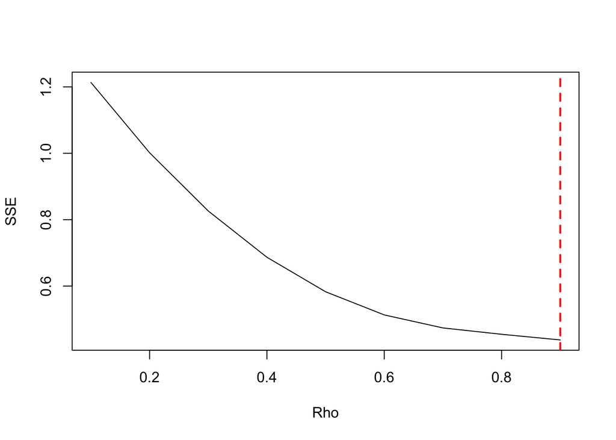

```r
#Grafik SSE optimum
par(mfrow = c(1,1))
plot(tab$SSE ~ tab$rho , type = "l", xlab = "Rho", ylab = "SSE")
abline(v = tabOpt[tabOpt$SSE==min(tabOpt$SSE),"rho"], lty = 2, col="red",lwd=2)
text(x=0.341, y=0.2397500, labels = "rho=0.341", cex = 0.8)
```

Perhitungan yang dilakukan aplikasi `R` menunjukkan bahwa nilai $ρ$ optimum, yaitu saat SSE terkecil terdapat pada nilai $ρ=0.900$. Hal tersebut juga ditunjukkan pada plot. Selanjutnya, model dapat didapatkan dengan mengevaluasi nilai $ρ$ ke dalam fungsi `hildreth.lu.func`, serta dilanjutkan dengan pengujian autokorelasi dengan uji Durbin-Watson. Namun, setelah pengecekan tersebut tidak lupa koefisien regresi tersebut digunakan untuk transformasi balik. Persamaan hasil transformasi itulah yang menjadi persamaan sesungguhnya.

```r
#Model terbaik
modelHL <- hildreth.lu.func(0.900, model)
summary(modelHL)
```

```
##
## Call:
## lm(formula = y ~ x1 + x2)
##
## Residuals:
##       Min        1Q    Median        3Q       Max
## -0.183778 -0.048288 -0.009294  0.044818  0.278212
##
## Coefficients:
##               Estimate Std. Error t value Pr(>|t|)
## (Intercept)  2.232e-01  2.784e-02   8.018 4.56e-11 ***
## x1           1.292e-05  5.527e-06   2.337   0.0228 *
## x2          -1.933e-06  7.805e-07  -2.476   0.0161 *
## ---
## Signif. codes:  0 '***' 0.001 '**' 0.01 '*' 0.05 '.' 0.1 ' ' 1
##
## Residual standard error: 0.08542 on 60 degrees of freedom
## Multiple R-squared:  0.09946,    Adjusted R-squared:  0.06944
## F-statistic: 3.313 on 2 and 60 DF,  p-value: 0.04317
```

```r
#Transformasi Balik
cat("y = ", coef(modelHL)[1]/(1-0.900), "+", coef(modelHL)[2],"x", sep = "")
```

```
## y = 2.232264+1.291627e-05x
```

[output not shown]

```r
#Deteksi autokorelasi
dwtest(modelHL)
```

```
##
##  Durbin-Watson test
##
## data:  modelHL
## DW = 2.1738, p-value = 0.7071
## alternative hypothesis: true autocorrelation is greater than 0
```

Terakhir, akan dibandingkan nilai SSE dari ketiga metode (metode awal, metode Cochrane-Orcutt, dan Hildreth-Lu).

```r
anova(model)
```

```
## Analysis of Variance Table
##
## Response: datafossil$`Per Capita`
##                          Df Sum Sq Mean Sq F value    Pr(>F)
## datafossil$`Gas Fuel`     1 4.7197  4.7197 156.925 < 2.2e-16 ***
## datafossil$`Liquid Fuel`  1 0.7742  0.7742  25.742 3.916e-06 ***
## Residuals                61 1.8346  0.0301
## ---
## Signif. codes:  0 '***' 0.001 '**' 0.01 '*' 0.05 '.' 0.1 ' ' 1
```

```r
#Perbandingan
sseModelawal <- anova(model)$`Sum Sq`[-c(1,2)]
sseModelCO <- anova(modelCOmanual)$`Sum Sq`[-c(1,2)]
sseModelHL <- anova(modelHL)$`Sum Sq`[-c(1,2)]
mseModelawal <- sseModelawal/length(datafossil$`Per Capita`)
mseModelCO <- sseModelCO/length(datafossil$`Per Capita`)
mseModelHL <- sseModelHL/length(datafossil$`Per Capita`)
akurasi <- matrix(c(sseModelawal,sseModelCO,sseModelHL,
                    mseModelawal,mseModelCO,mseModelHL),nrow=2,ncol=3,byrow = T)
colnames(akurasi) <- c("Model Awal", "Model Cochrane-Orcutt", "Model Hildreth-Lu")
row.names(akurasi) <- c("SSE","MSE")
akurasi
```

```
##     Model Awal Model Cochrane-Orcutt Model Hildreth-Lu
## SSE 1.83464192           0.468131994       0.437820470
## MSE 0.02866628           0.007314562       0.006840945
```

Berdasarkan hasil tersebut dapat diketahui bahwa hasil penanganan autokorelasi dengan metode Cochrane-Orcutt dan Hildreth-Lu memiliki SSE yang tidak jauh berbeda, sebesar 0.4681 dan $0.4378$ yang lebih baik dibandingkan model awal ketika autokorelasi masih terjadi, yaitu sebesar $1.83464192$.

# Simpulan

Autokorelasi yang terdapat pada data foss il fuelterjadi akibat adanya korelasi di antara unsur penyusunnya. Indikator carbon percapita yang erat hubungannya dengan pengeluaran gas fuel dan liquid fuel yang dihasilkan dapat menjadi penyebab adanya autokorelasi. Adanya autokorelasi menyebabkan model regresi kurang baik karena akan meingkatkan galatnya. Autokorelasi dapat dideteksi secara eksploratif melalui plot sisaan, ACF, dan PACF, serta dengan uji formal Durbin-Watson. Namun, autokorelasi tersebut dapat ditangani dengan metode Cochrane-Orcutt dan Hildreth-Lu. Kedua metode menghasilkan nilai SSE yang lebih kecil dari original, artinya keduanya baik untuk digunakan.